# AM108 Project

Ali Crump

11/24/2019

### Baseball graph replication

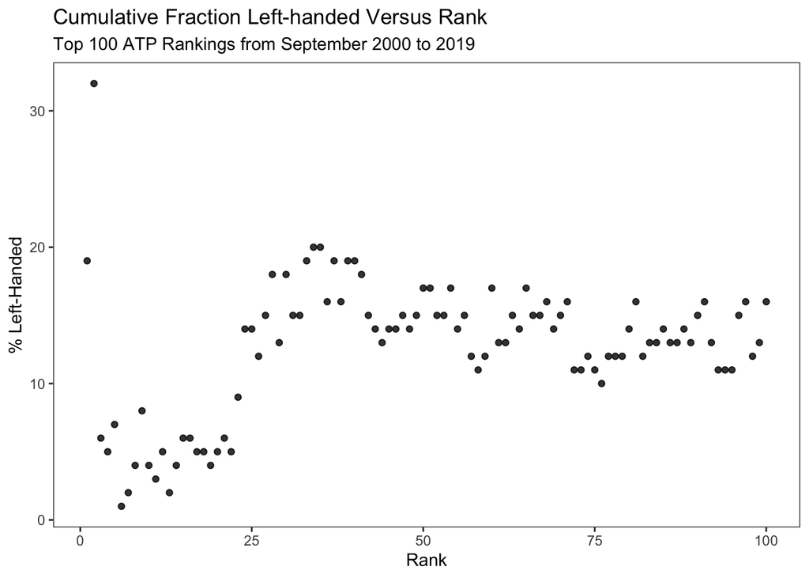

### Do we always see a dip?

Our original theory was that we see this dip in the top 25 rankings because of the dominance of lefty Rafael Nadal. Perhaps righties at the top were used to playing really talented lefties like Nadal, so the lefty advantage in competitive sports disappears. I filtered for years before Nadal was so dominant and used the same methods to create this graph. However, we see below that there is a “dip” in the top rankings even when Nadal isn’t dominant. Therefore, there is something else going on in professional tennis that our model isn’t accounting for, or this is a really odd set of circumstances that just happens by chance to be the case for the data at hand.

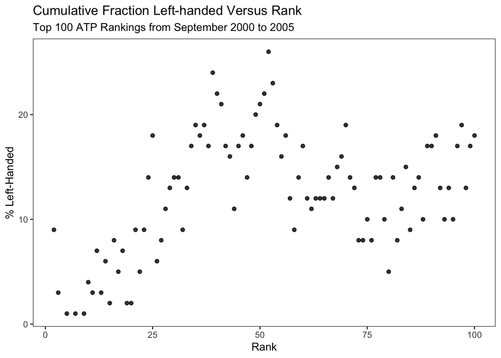

### Data exploration

We were curious to see how many lefties had even been in the top 25 rankings consistently, or if it really was just Nadal. We find that 6 left handers have consistently been in the top 25, consistently meaning in the top 25 for more than a year. We were suprised by how low this number was.

```
## # A tibble: 6 x 1
## # Groups:   Player [6]
##   Player
##   <chr>
## 1 Rafael Nadal
## 2 Feliciano Lopez
## 3 Fernando Verdasco
## 4 Jurgen Melzer
## 5 Jarkko Nieminen
## 6 Mariano Puerta
```

### Left-handedness over time

We were curious as to how the left handed population changes over time, but it’s very messy because I didn’t know how to plot it by year, so the graph shows the lefty percent for 52 weeks of rankings for 20 years.

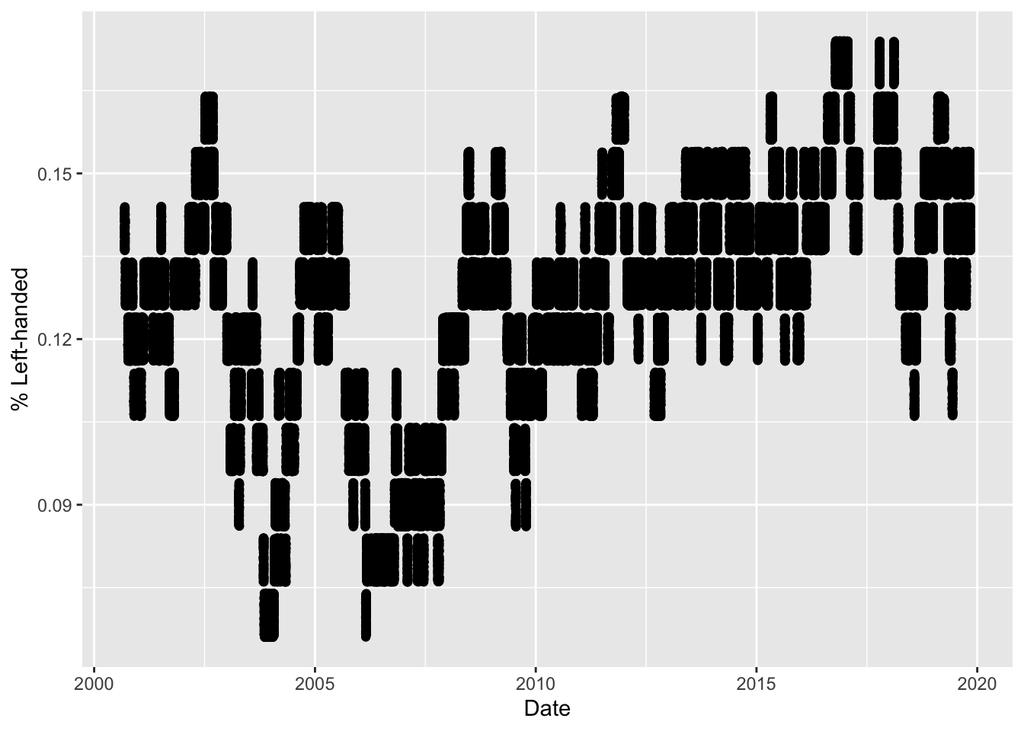

### Agent-based model results

We used an agent-based model to simulate the left handed population in tennis for many years.

This graph shows the results of one simulation where we see a dip, like what we saw with our actual tennis data.

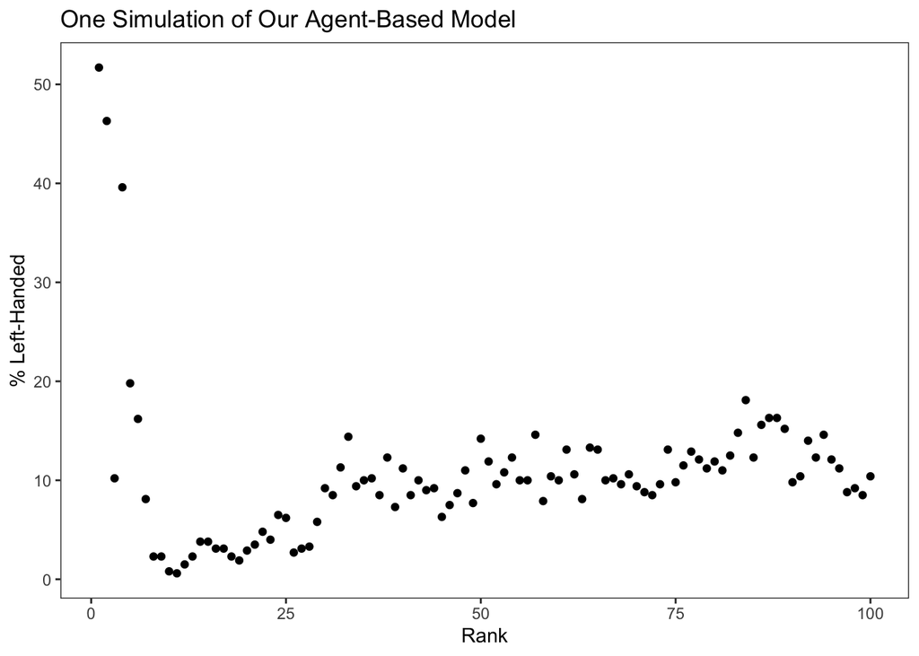

This graph then shows the average of all of our simulations, we no longer see a dip, as the dip only happened about 30% of the time in our simulations.

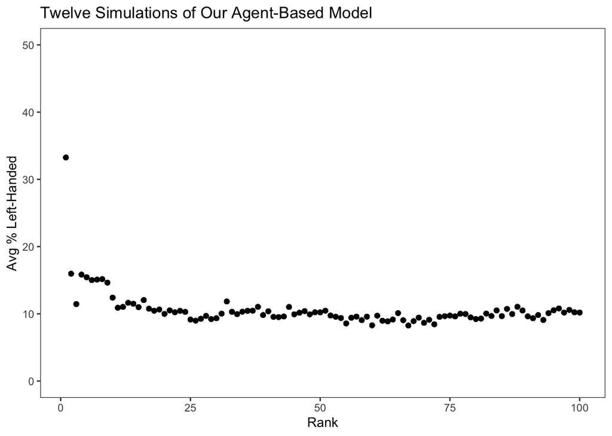